# LUMAS-analysis

### Analysing effects

```r
## Analyse fixed effects

# get mode + HDI for each parameter
fixedsum <- mod_noint %>%
  gather_draws(`(b_.*)|(sd_.*)|(r_s.*)`, regex = TRUE) %>% mode_hdi(.width = .89) %>%
  mutate(exp = exp(.value))

fixedsum %>% print(n = Inf)
```

```
## # A tibble: 25 x 8
##    .variable               .value   .lower  .upper .width .point .interval   exp
##    <chr>                    <dbl>    <dbl>   <dbl>  <dbl> <chr>  <chr>     <dbl>
##  1 b_decline_difficulty  -4.83e-2 -0.168    0.0399   0.89 mode   hdi       0.953
##  2 b_disproportionality  -8.63e-2 -0.218    0.0367   0.89 mode   hdi       0.917
##  3 b_Intercept           -1.55e+0 -2.64    -0.519    0.89 mode   hdi       0.213
##  4 b_ongoing_control      2.11e-1  0.0828   0.363    0.89 mode   hdi       1.23
##  5 b_participant_benefit  2.58e-1  0.136    0.416    0.89 mode   hdi       1.29
##  6 b_private_benefit     -4.29e-2 -0.170    0.0642   0.89 mode   hdi       0.958
##  7 b_public_benefit       1.37e-1  0.00752  0.289    0.89 mode   hdi       1.15
##  8 b_respect_for_privacy  5.41e-1  0.359    0.695    0.89 mode   hdi       1.72
##  9 b_risk_of_harm        -2.89e-1 -0.454   -0.144    0.89 mode   hdi       0.749
## 10 b_security             1.20e-1 -0.00749  0.297    0.89 mode   hdi       1.13
## 11 b_sensitivity         -2.43e-1 -0.430   -0.102    0.89 mode   hdi       0.784
## 12 b_trust                4.91e-1  0.335    0.683    0.89 mode   hdi       1.63
## 13 r_scenario[Academic.~ -4.05e-2 -0.597    0.314    0.89 mode   hdi       0.960
## 14 r_scenario[Memory.fo~  2.85e-2 -0.434    0.565    0.89 mode   hdi       1.03
## 15 r_scenario[Project.F~  3.72e-1 -0.134    1.10     0.89 mode   hdi       1.45
## 16 r_scenario[Project.M~  2.94e-2 -0.474    0.525    0.89 mode   hdi       1.03
## 17 r_scenario[Project.P~  2.65e-4 -0.495    0.443    0.89 mode   hdi       1.00
## 18 r_scenario[Project.Q~ -5.12e-1 -1.01     0.0729   0.89 mode   hdi       0.599
## 19 r_scenario[Project.T~ -3.57e-1 -0.919    0.115    0.89 mode   hdi       0.700
## 20 r_scenario[Safe.Camp~  4.17e-2 -0.410    0.530    0.89 mode   hdi       1.04
## 21 r_scenario[Serving.y~  3.02e-2 -0.336    0.641    0.89 mode   hdi       1.03
## 22 r_scenario[Student.W~ -6.16e-2 -0.590    0.356    0.89 mode   hdi       0.940
## 23 r_scenario[Work.Reco~  5.07e-1 -0.0869   1.02     0.89 mode   hdi       1.66
## 24 sd_ResponseId__Inter~  8.63e-1  0.397    1.28     0.89 mode   hdi       2.37
## 25 sd_scenario__Interce~  4.19e-1  0.114    0.780    0.89 mode   hdi       1.52
```

```r
## Get ROPE (Range of Practical Equivalence)
p <- mean(d_pass$is_acceptable)
neglig <- .05 # a 5% change over range of variables is practically relevant.
ROPEpos <- (logit(p + neglig) - logit(p - neglig))/5
ROPEpos
```

```
## [1] 0.09828348
```

```r
# get Percentage of mode + 89% HDI in ROPE
rope_perc <- rope(mod_noint, range = c(-ROPEpos, ROPEpos)) %>%
  dplyr::select(Parameter, ROPE_Percentage) %>%
  data.frame() %>%
  filter(Parameter != "b_Intercept") %>%
  mutate(ROPE_Percentage = paste0(round(as.numeric(ROPE_Percentage), 4) *100, "%"))

rope_perc
```

```
##                Parameter ROPE_Percentage
## 1   b_decline_difficulty           74.3%
## 2      b_private_benefit          79.44%
## 3  b_participant_benefit              0%
## 4       b_public_benefit          26.93%
## 5   b_disproportionality          56.02%
## 6          b_sensitivity              0%
## 7         b_risk_of_harm              0%
## 8                b_trust              0%
## 9             b_security          32.01%
## 10     b_ongoing_control           3.54%
## 11 b_respect_for_privacy              0%
```

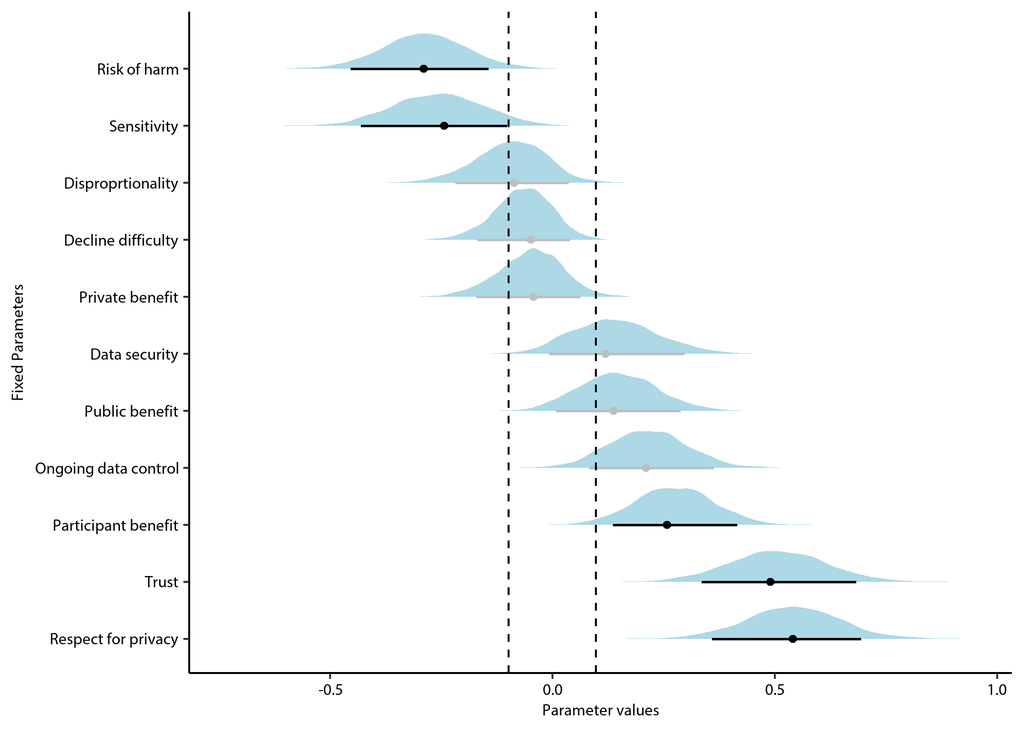

```r
## GRAPH FIXED EFFECT POSTERIORS ##

showtext_auto()
showtext_opts(dpi = 300)

## set text size - https://stackoverflow.com/questions/25061822/ggplot-geom-text-font-size-control
theme.size <- 8
geom.text.size <- theme.size / (14/5)

## get posteriors generally
postINT <- mod_noint %>%
  gather_draws(`b_.*`, regex = TRUE) %>%
  filter(.variable != "b_Intercept") %>%
  ggplot(aes(y = fct_reorder(.variable, .value, .fun = "mean", .desc = TRUE),
             x = .value)) +
  stat_slab(fill = "lightblue", alpha = 1) +
  stat_pointintervalh(point_interval = mode_hdi, .width = c(.89),
                      aes(col = stat(xmax > -.098 & xmin < .098)), size = 1) +
  geom_vline(xintercept = c(-.098, .098), linetype = "dashed") +
  scale_colour_manual(values = c("black", "gray")) +
  xlab("Parameter values") +
  ylab("Fixed Parameters") +
  #annotate("text", x=0, y=1, label= "ROPE")  +
  theme_pubr() +
  theme(legend.position = "none",
        text = element_text(family = "Myriad Pro", size = 8)) +
  scale_y_discrete(label = rev(c("Risk of harm", "Sensitivity", "Disproprtionality",
                             "Decline difficulty", "Private benefit", "Data security",
                             "Public benefit" ,"Ongoing data control", "Participant benefit",
                             "Trust", "Respect for privacy")))
  #geom_text(aes(x = 0.005, y = Parameter, label = ROPE_Percentage), data = rope_perc, vjust = -.5) #- to add percentage in ROPE to graph
postINT
```

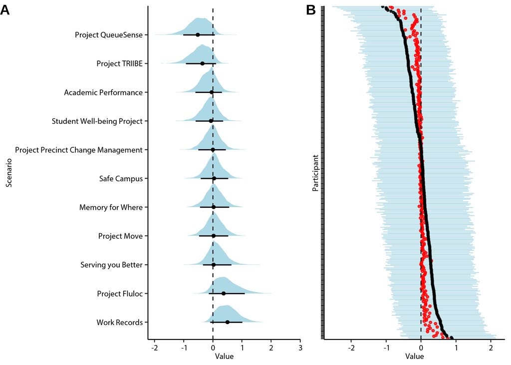

```r
ggsave("images/posteriorsINT.png", width = 3.5, height = 5, units = "in", dpi = 300)

## GRAPH RANDOM EFFECT POSTERIORS ##

##scenario
scens.alph <- sort(c("Work Records", "Memory for Where","Serving you Better", "Safe Campus",
           "Student Well-being Project", "Project Move", "Project TRIIBE",
           "Project QueueSense", "Project Fluloc","Project Precinct Change Management",
            "Academic Performance"))

randscen <- mod_noint %>%
  gather_draws(r_scenario[scenario, term]) %>%
  ungroup() %>%
  mutate(scenario = factor(scenario, labels = scens.alph)) %>%
  group_by(scenario) %>%
  ggplot(aes(x = .value, y = fct_reorder(scenario, .value, .fun = mean, .desc = TRUE))) +
  ylab("Scenario") +
  xlab("Value") +
  stat_halfeyeh(point_interval = "mode_hdi", .width = c(.66, .89),
                fill = "lightblue", alpha = 1, col = "black", size = 1) +
  theme_pubr() +
  theme(text = element_text(family = "Myriad Pro", size = 8)) +
  geom_vline(xintercept = 0, linetype = "dashed")
ggsave("images/randposteriorsscen.png", width = 5, height = 5, units = "in", dpi = 300)

## Participant
randpart <- mod_noint %>%
  gather_draws(r_ResponseId[participant, term]) %>%
  ggplot(aes(x = .value, y = fct_reorder(participant, .value, .fun = mean, .desc = TRUE))) +
  ylab("Participant") +
  xlab("Value") +
  stat_pointinterval(point_interval = "mode_hdi", .width = c(.89),
                     alpha = .75, col = "lightblue", size = 0.125, point_colour = "red") +
  stat_summary(fun = "mean",
                     alpha = .75, col = "black", size = 0.125) +
  theme_pubr() +
  theme(text = element_text(family = "Myriad Pro", size = 8),
        axis.text.y = element_blank()) +
  geom_vline(xintercept = 0, linetype = "dashed")
ggsave("images/randposteriorspart.png", width = 5, height = 9, units = "in", dpi = 300)

# JOIN GRAPHs together
cowplot::plot_grid(randscen, randpart, ncol = 2, rel_widths = c(3, 2), labels = 'AUTO', hjust = 0)
```

```r
ggsave("images/randCOMB.png", width = 7, height = 5, units = "in", dpi = 300)

#turn off showtext
showtext_auto(FALSE)
```

### Model diagnostics

#### Traceplots, rhat, ESS etc.

Analysis of various diagnostic plots show that:

- the mcmc draws are accurately sampling the posterior.
- the chains all converge will all Rhat’s very close to 1.
- the effective sample size for each parameter was acceptable (all above the rule of thumb of 0.1)
- the bivariate distributions show no parameters that are ‘trading off’ in their parameter values
- autocorrelation remains low, with the exception of the sd parameters (this is refelcted in smaller ESS)

For more informatoin on these diagnostics see https://mc-stan.org/bayesplot/articles/visual-mcmc-diagnostics.html

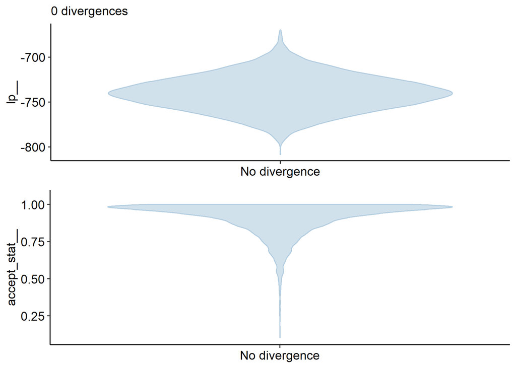

```r
#get nuts information and log_posterior info
mod_np <- nuts_params(mod_noint)
mod_lp <- log_posterior(mod_noint)

# nuts sampling diagnostics
mcmc_nuts_divergence(mod_np, mod_lp)
```

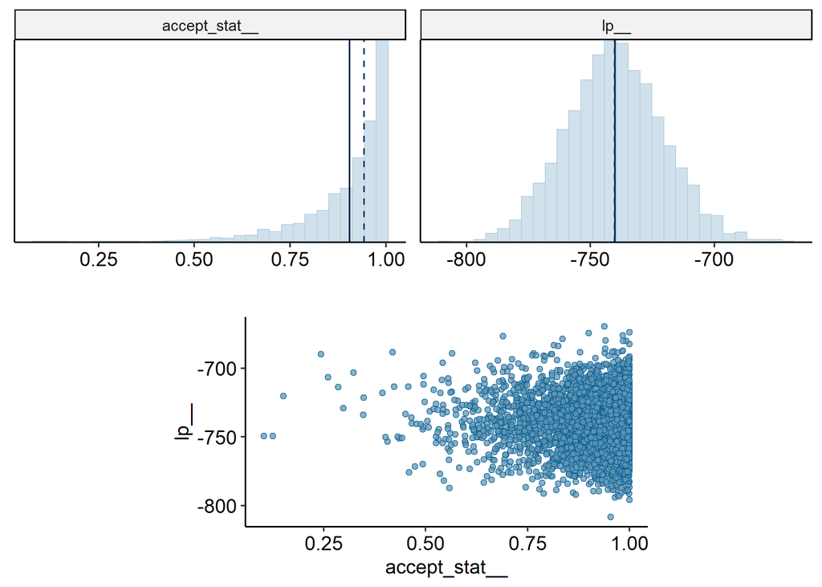

```r
mcmc_nuts_acceptance(mod_np, mod_lp)
```

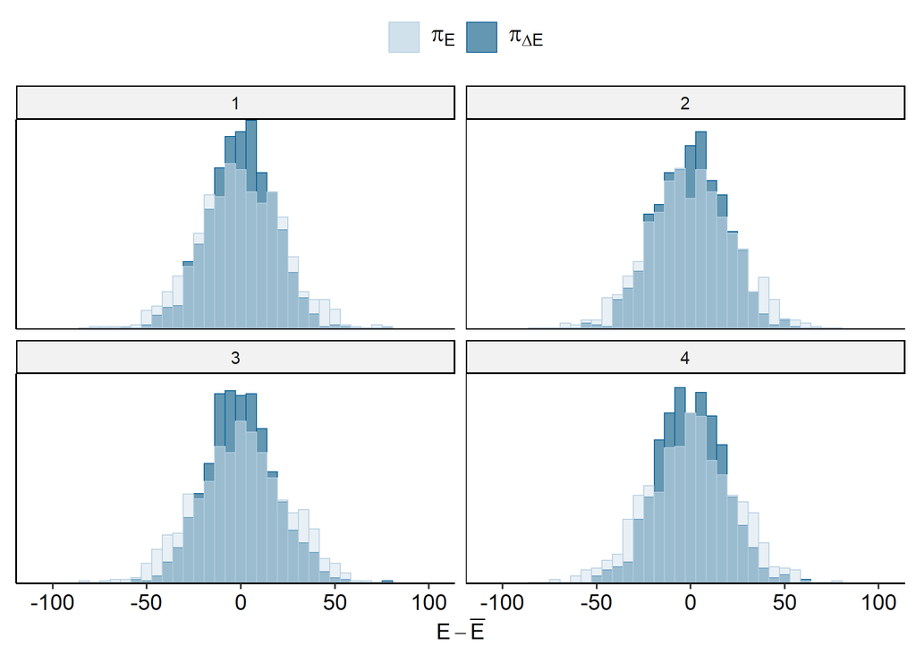

```r
mcmc_nuts_energy(mod_np, mod_lp)
```

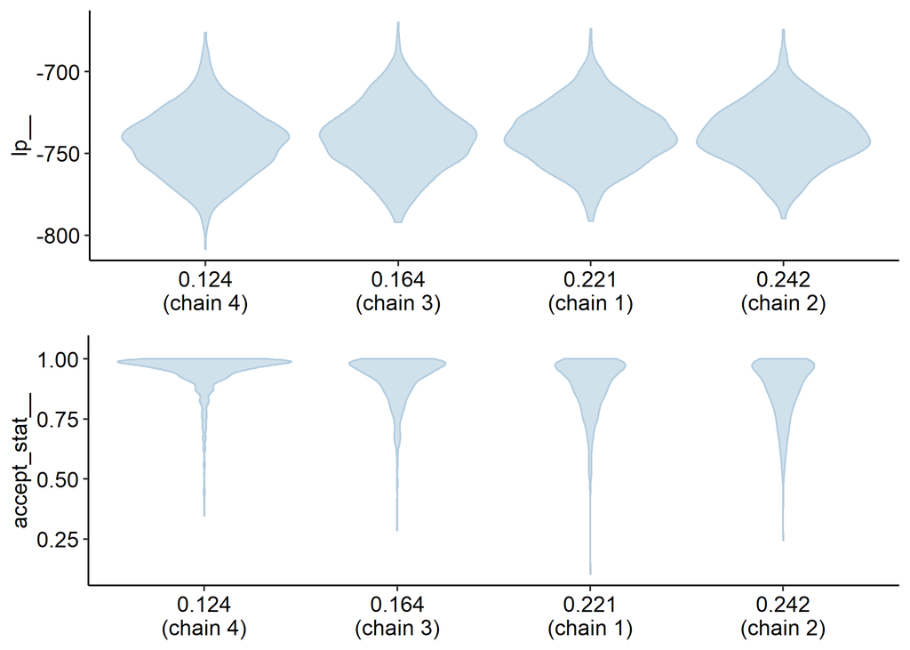

```r
mcmc_nuts_stepsize(mod_np, mod_lp)
```

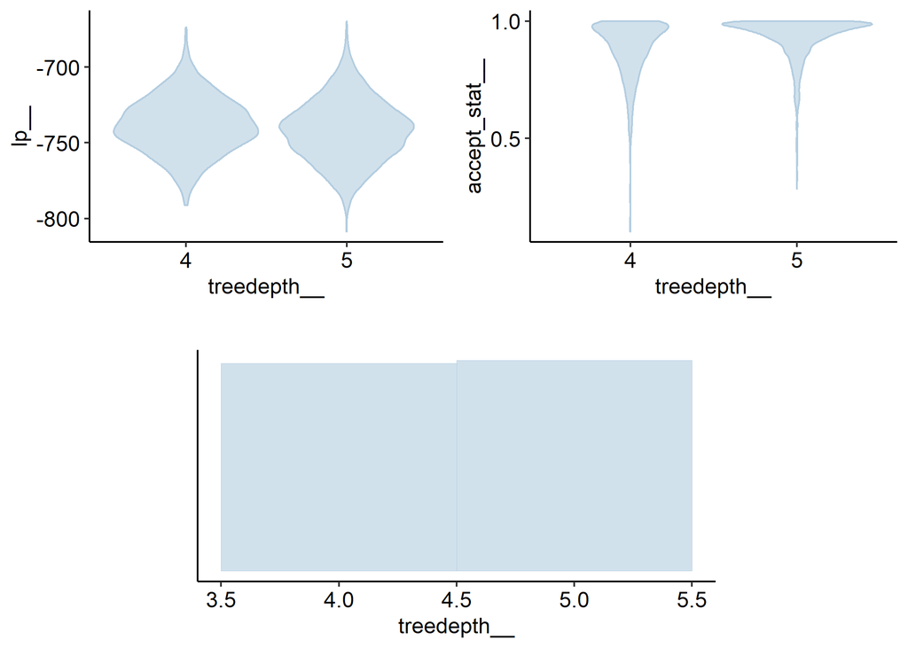

```r
mcmc_nuts_treedepth(mod_np, mod_lp)
```

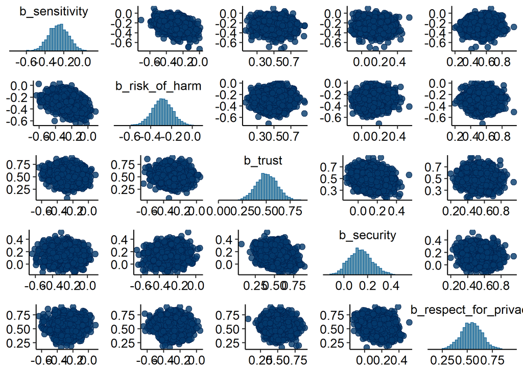

```r
# check bivariate distributions of parameters with high correlations
mcmc_pairs(mod_noint, pars = c("b_sensitivity", "b_risk_of_harm", "b_trust", "b_security", "b_respect_for_privacy"))
```

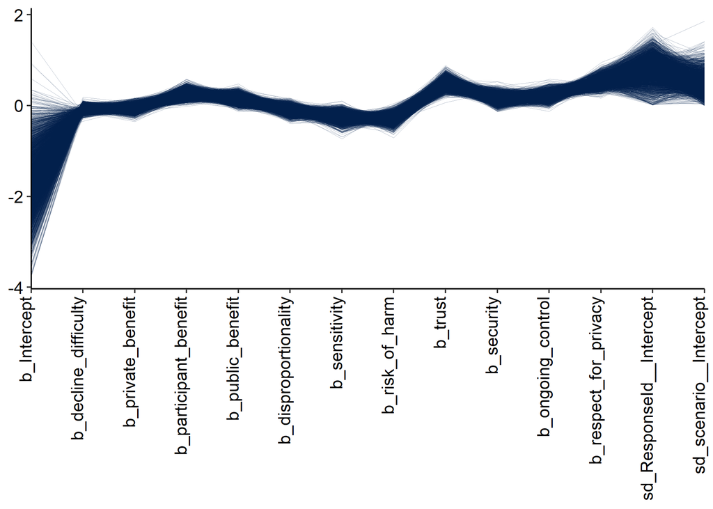

```r
#check parameters in each iteration (one line per iteration) to check convergence and see any other patterns
mcmc_parcoord(mod_noint, pars = vars(b_Intercept:sd_scenario__Intercept)) + xaxis_text(angle = 90, hjust = 1, vjust = 0.00)
```

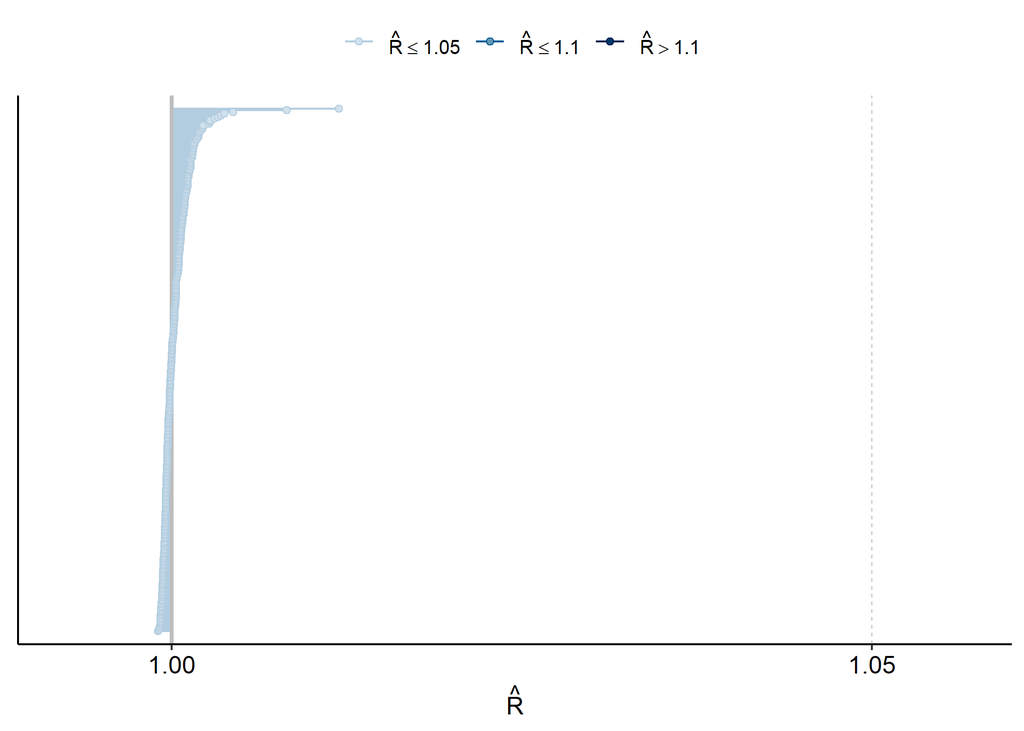

```r
# rhat
mcmc_rhat(rhat(mod_noint))
```

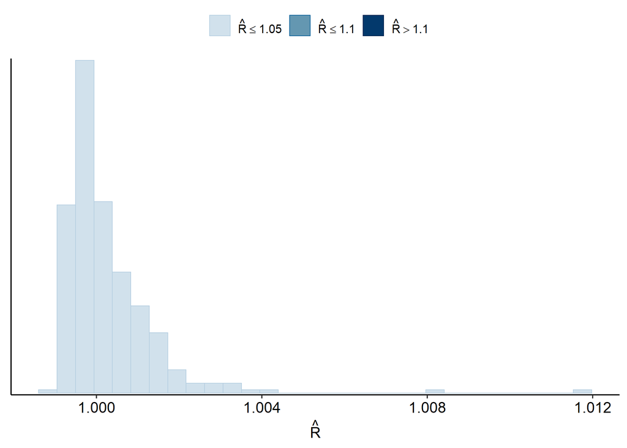

```r
mcmc_rhat_hist(rhat(mod_noint))
```

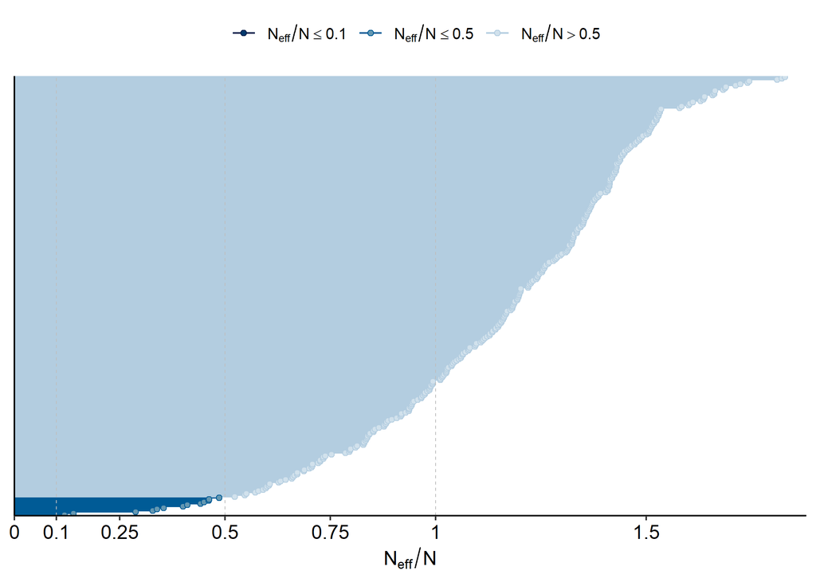

```r
# Effective sample size ratio
mcmc_neff(neff_ratio(mod_noint))
```

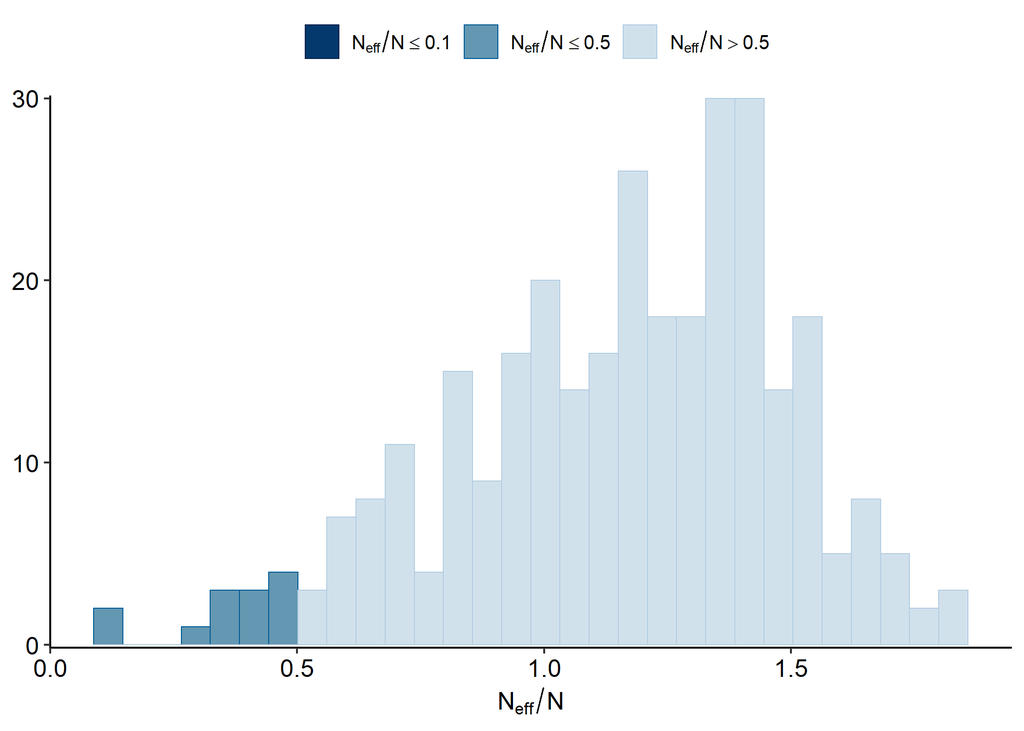

```r
mcmc_neff_hist(neff_ratio(mod_noint))
```

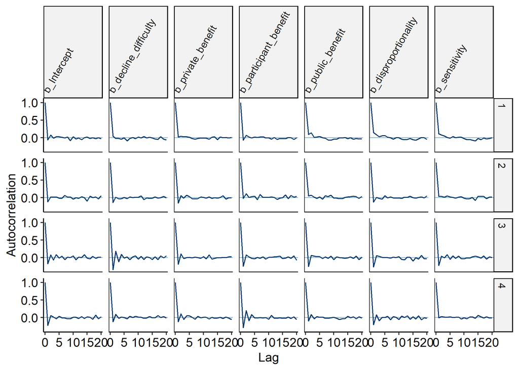

```r
# autocorrelation
mcmc_acf(mod_noint, pars = vars(b_Intercept:b_sensitivity) ) + facet_text(angle = 60, hjust = 0, vjust = 0.00)
```

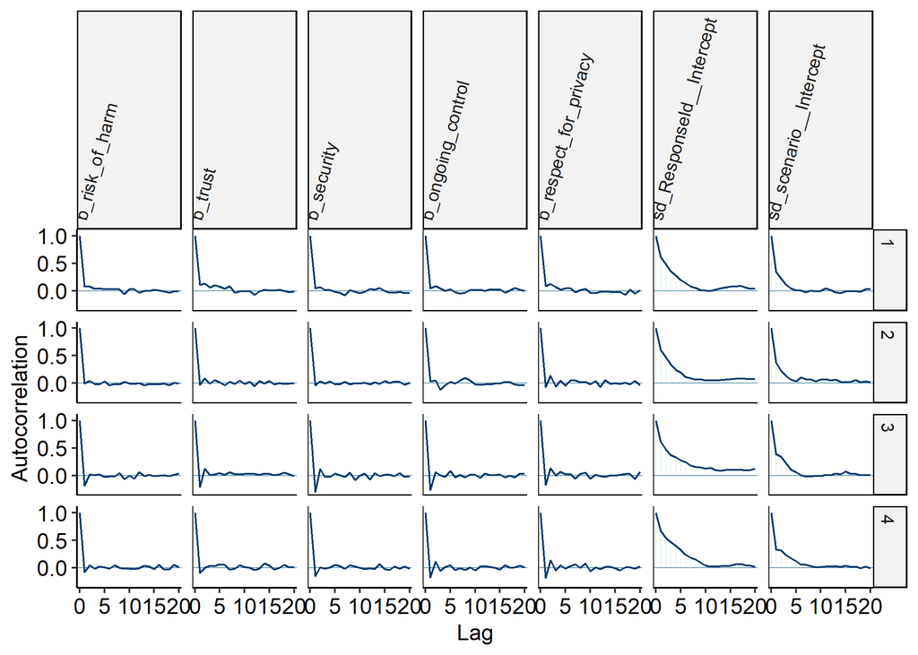

```r
mcmc_acf(mod_noint, pars = vars(b_risk_of_harm:sd_scenario__Intercept))  + facet_text(angle = 75, hjust = 0, vjust = 0.00)
```

```r
#sd paramaters struggling with autocorrelation (explains their lower ess measures)
```